# Lab 8

### Objectives

To integrate the subsystems constructed so far and test a complete audio amplifier system.

### Integration and testing

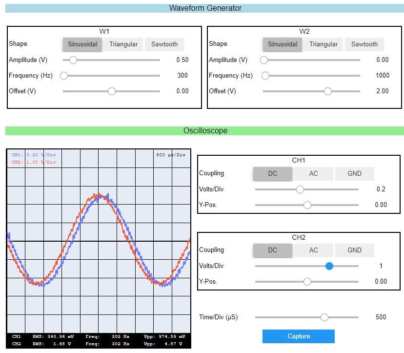

[figure not shown]

## V Audio (Vpp)

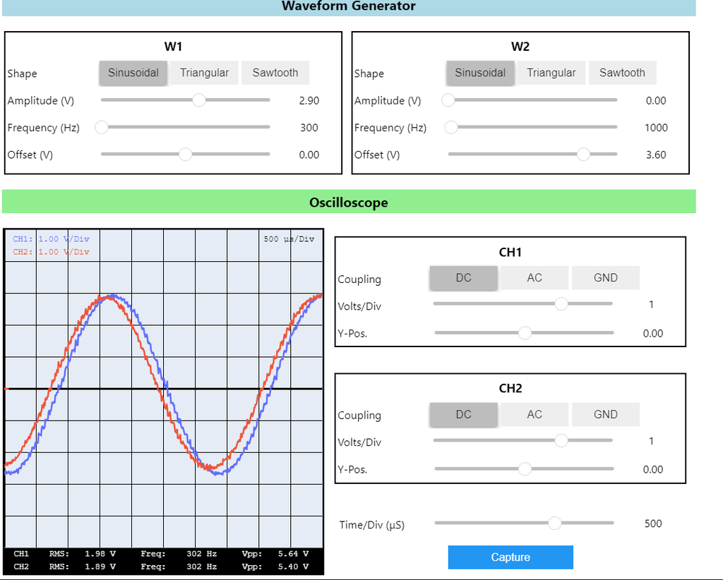

## V Volume (Vrms)

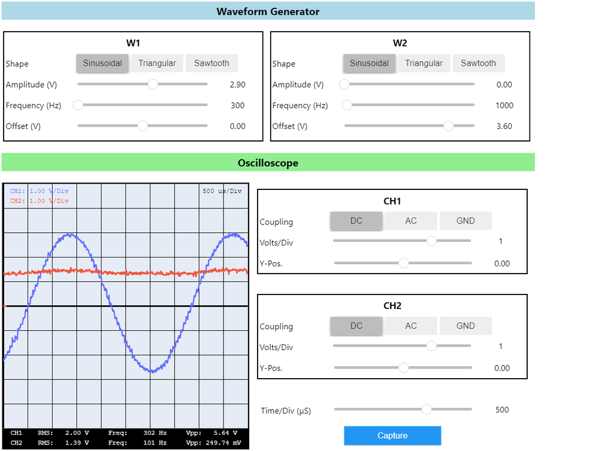

### Audio amplifier characterization

```python
import numpy as np
import plotly.graph_objs as go

v_a = np.array([5.4, 4.5, 3.6, 2.7, 1.8, 0.9, 0, -0.9])
vpp_signal = np.array([9.04, 7.29, 5.47, 3.81, 1.92, 0.994, 0.498, 0.53])
vpp_audio = np.array([1.51, 2.9, 5.37, 9.03, 9.86, 4.7, 8.43, 10.94])
vrms_volumne = np.array([0.149, 0.527, 1.31, 2.48, 2.79, 2.89, 3.49, 2.21])

v_c = v_a*(33/593)
gain_audio = 20*np.log10(vpp_audio/vpp_signal)

# Create figure with secondary y-axis
fig = go.Figure()

fig.add_trace(go.Scatter(x=v_c, y=gain_audio, mode='markers', name='Gain (dB)'))
fig.update_layout(xaxis_title='V<sub>C</sub>', yaxis_title='Gain (dB) at V<sub>audio</sub>')

coef = np.polyfit(v_c, gain_audio, deg=1) # deg=1 for order 1 polynomial (linear)
fit = coef[0]*v_c + coef[1]
fig.add_trace(go.Scatter(x=v_c, y=fit, mode='lines', line=dict(dash='dash'), name='Best fit for Gain at V<sub>audio</sub>'))
```

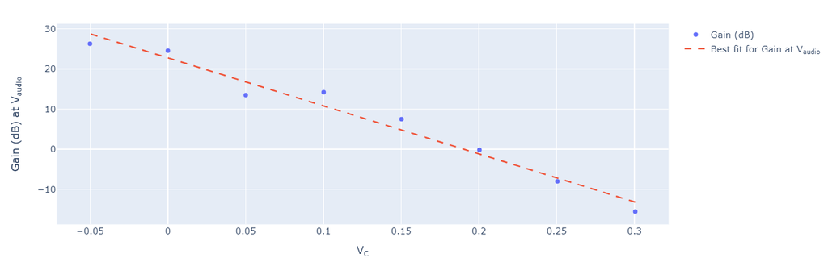

**Plot the graph of the gain versus 𝑉c, and discuss whether the output performance of the audio amplifier system meets the desired objective**

Based on the results, the lower Vc would produce a higher gain. Which would mean that the audio produce is louder. This aligns with Lab 5. Since Vc is propotional to Va, having a very low Va would cause the highest gain with potentially could cause clipping and distortion. The output performance of the graph indicates that the audio amplifier meets the desired objective.

### Open-Ended Questions

**Describe the problems you encountered when integrating the circuit and manually controlling the volume. How did you troubleshoot the problems?**

There was human error in integrating the circuits where the initial graph is not produced correctly. Adjustung the Volume (Va) was confusing and adjusting the Va too low would cause the speaker to be too loud and more distorted. Speaker also produce a humming/buzzing noise while the audio is playing. With this in mind, adjusting the Va to a higher voltage and then slowly decreasing the voltage produced a better audio.Also, double checking the circuit for loose connections helped with the buzzing noise. It can be concluded that using longer wires / more wires will cause the circuit to have more resistance and therefore affect the audio output. Minimising the number of wires / length of wires would help improve. Lastly, better components inclusive of speakers and audio wires and Op Amp would help produce the cleaner audio with lesser noise to the audio. A high-quality opamp can help improve the SNR of a microphone amplifier. Opamps having a low noise floor and high gain are best suited for achieving a high SNR. Furthermore, correct circuit design and shielding techniques can assist minimise noise and increase SNR.